# Keywords Searching using Twitter API in R & Python

2022-09-14

## Data Collected Link

[Tweets text data that are collected can be found here](https://github.com/anly501/anly-501-project-yeyaxin1103/tree/main/data/00-raw-data/twitter_api_data)

## Data Gathering Method & Data Source Explained

In this part, I searched the keyword “fertility rate” using Twitter API in Korean, Japanese, Chinese, and English. The purpose is to explore people’s perspectives in East Asia when they talk about the birth rate issue.

The reason why I chose to conduct the keyword searching in these three languages not only because they are the mostly used languages in Eastern Asia but also because people there tend to express their opinions in their first languages due to limited and inconsistent English education levels in that region.

However, since this research project is conducted in English and will mainly be read by English readers, it is necessary to collect tweets from English-speaking individuals for broader perspectives.

The purpose of gathering Tweets data is for future word clouds generations and possible sentiment analysis.

### Data Gathering Process using Twitter API in R

```r
library(selectr)
library(rvest)
library(xml2)
library(rtweet) # for scraping tweets
library(wordcloud2) # for generating really cool looking word clouds
library(NLP) #required to load tm
library(tm) # for text mining
library(dplyr) # loads of fun stuff including piping
library(ROAuth)
library(jsonlite)
library(httpuv)
```

Setting API parameters

```r
api = read.csv('twitter_api_info.txt')

consumer_key = as.character(api[api["Type"] == "Consumer Key"][2])
consumer_secret = as.character(api[api["Type"] == "Consumer Secret"][2])
access_token = as.character(api[api["Type"] == "Access Token"][2])
access_token_secret = as.character(api[api["Type"] == "Access Token Secret"][2])
bearer_token = as.character(api[api["Type"] == "Bearer Token"][2])
```

Extracting tweets

```r
library(twitteR)
library(rtweet)

s_key_kr = '출생률'
s_key_jp = '出生率'
s_key_cn = '生育率'

n_tweets = 500

twitteR::setup_twitter_oauth(consumer_key, consumer_secret, access_token, access_token_secret)
```

```
## [1] "Using direct authentication"
```

```r
auth_setup_default()

#Search_kr <- twitteR::searchTwitter(s_key_kr, n = n_tweets, since = "2017-01-01")
#Search_jp <- twitteR::searchTwitter(s_key_jp, n = n_tweets, since = "2017-01-01")
#Search_cn <- twitteR::searchTwitter(s_key_cn, n = n_tweets, since = "2017-01-01")

#TweetsDF_kr <- twListToDF(Search_kr)
#TweetsDF_jp <- twListToDF(Search_jp)
#TweetsDF_cn <- twListToDF(Search_cn)

Tweets_kr <- search_tweets(s_key_kr, n_tweets, lang = 'ko')
Tweets_jp <- search_tweets(s_key_jp, n_tweets, lang = 'ja')
Tweets_cn <- search_tweets(s_key_cn, n_tweets)
```

Take a closer look at the example tweets that were pulled using the keyword “birth rate” in Korean, Japanese, and Chinese:

```r
##Example Korean tweet:
Tweets_kr$text[3]
```

```
## [1] "리) 2030 남녀 간의 정치관이 서로 다르게 분포하는 것도 장기적으로 문제. 정치 종교관은 시간 지난다고 쉽게 바뀌는 것도 아니고, 안 맞는 사람과는 함께 지내기도 어려우니 혼인과 출생률은 더 떨어지겠네. 특정 정치권의 갈라치기가 나라의 미래를 물리적으로 절단냈군."
```

```r
###Example Japanese tweet:
Tweets_jp$text[4]
```

```
## [1] "RT @Chinami80130365: イーロン・マスク『世界のほとんどの人は、「人が多すぎる」という誤った印象のもとに行動しています。これは真実ではありません。地球は現在の何倍もの人口を維持することができます。出生率は驚くほど低下しています。』\n\nこんな見解もあるんですね。…"
```

```r
####Example Chinese tweet:
Tweets_cn$text[5]
```

```
## [1] "🙏女人的体重对生育能力有很大影响。 \n💙 科学家们开发出了一个体重指数,可以确定生孩子的机会。\n👉 正常体重指数从18.5到25。\n👉你的体重指数接近25,怀孕的机率增加4%。\n💙记住超重会降低生育力,所以在计划怀孕时考虑你的体重指数,如果有必要,请开始健康饮食。\n👉 下图将帮助您计算质量指数 https://t.co/Zp4ggAFE72"
```

```r
## Saving the tweets to files
fname_kr = "./tweetsKR.txt"
fname_jp = "./tweetsJP.txt"
fname_cn = "./tweetsCN.txt"

## Start the files
file_kr <- file(fname_kr)
file_jp <- file(fname_jp)
file_cn <- file(fname_cn)

## Write tweets to the files
cat(unlist(Tweets_kr), " ", file=file_kr, sep="\n")
cat(unlist(Tweets_jp), " ", file=file_jp, sep="\n")
cat(unlist(Tweets_cn), " ", file=file_cn, sep="\n")
```

### Snapshots of the Raw Twitter Text Data Gathered in R

Now we can take a look at the screenshots of the Tweets we pulled from Twitter using the keyword “birth rate” in Korean, Japanese, and Chinese.

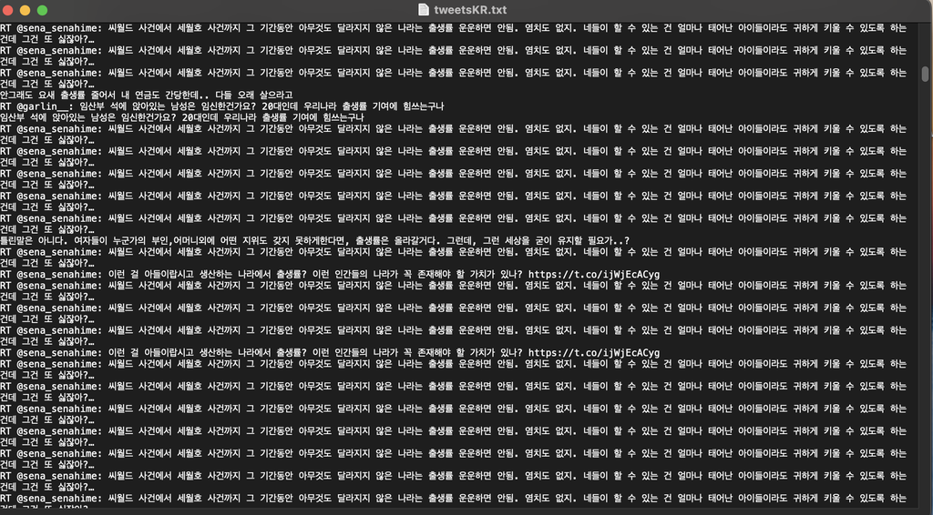

```r
knitr::include_graphics("./tweetsKR_snapshot.png")
```

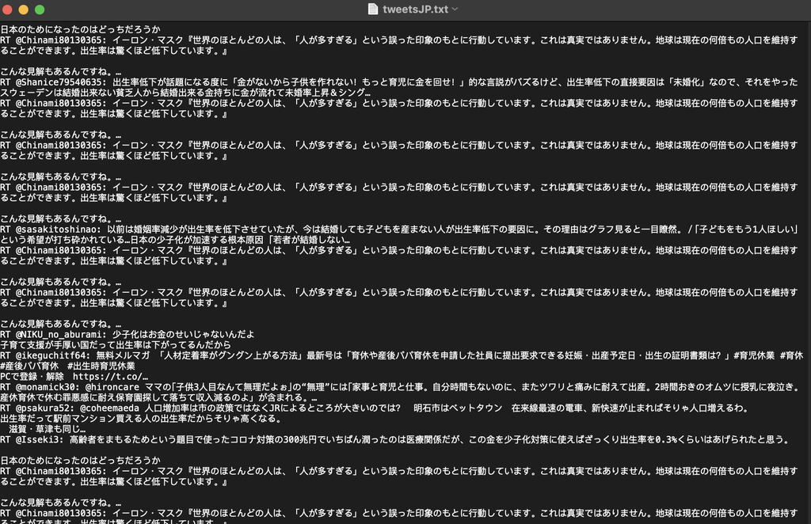

```r
knitr::include_graphics("./tweetsJP_snapshot.png")
```

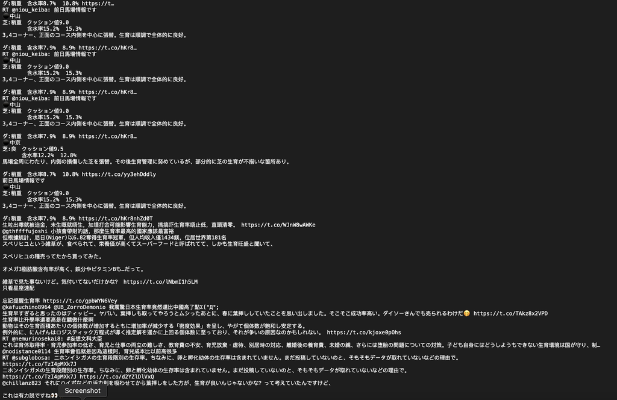

```r
knitr::include_graphics("./tweetsCN_snapshot.png")
```

## Data Gathering Process using Twitter API in Python

[Code of using Twitter API in Python can be found here](https://github.com/anly501/anly-501-project-yeyaxin1103/blob/main/codes/01-data-gathering/API_gathering.py)

### Snapshots of the Raw Twitter Text Data Gathered in Python

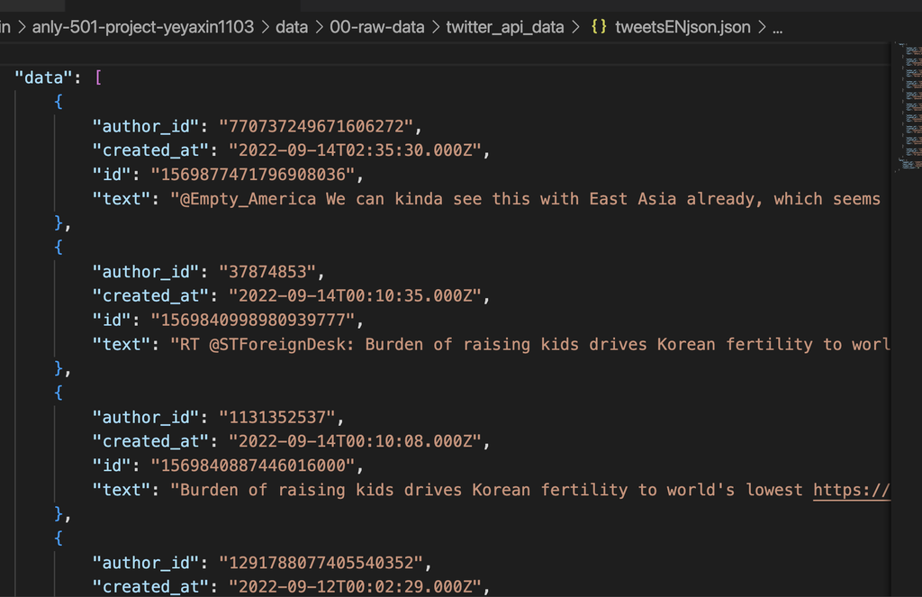

```r
knitr::include_graphics("./tweetsEN_snapshot.png")
```